# PSTAT194 CS Section 6

Yue(Yuri) He

Spring 2022

```r
library(ggplot2)
library(dplyr)
library(tidyr)
```

## Monte Carlo Integration

Recall, suppose $X\sim f$, and we are interested in $E_f{h(X)}$ where
$$E_f[{h(X)}]=\int_{-\infty}^{\infty}h(x)f(x)dx\equiv\mu$$
If $X_1,...X_n \overset{\text{i.i.d}}{\sim}f$, then one can approximate $\mu$ by
$$\hat{\mu}_{MC}=\frac{1}{n}\sum_{i=1}^nh(x_i)$$
where MC $=$ Monte Carlo, since $\hat{\mu}_{MC}\underset{\text{a.s}}{\longrightarrow}\int_{-\infty}^{-\infty}h(x)f(x)dx=E_f{h(X)}$ as n$\rightarrow\infty$ if $E_f{|h(X_i)|}<\infty$ $\forall i$ by Strong Law of Large Numbers.

### HW3 Exercise 2

Use Monte Carlo integration to estimate

1. $$\int_{0}^{2} \cos(x*e^x) dx$$

Area estimation:

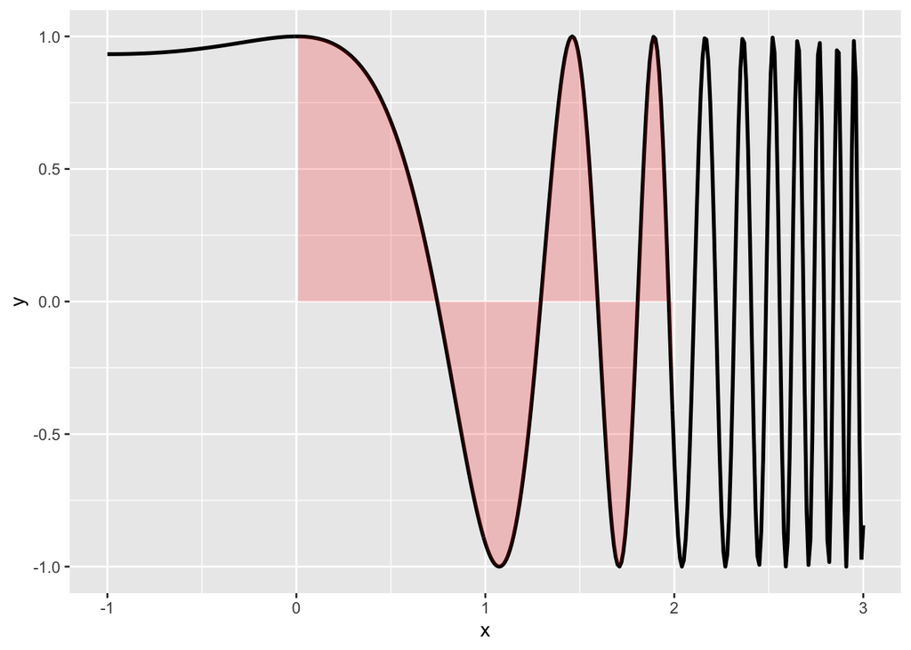

```r
desired_fun <- function(x){
  cos(x*exp(x))
}
x <- seq(-1,3,by=0.01)
y <- desired_fun(x)
df <- data.frame(x,y)
ggplot(df, aes(x,y)) +
  # theme_minimal() +
  geom_line(size=1) +
  geom_ribbon( data=subset(df, x>0 & x<2), aes(ymin=0,ymax=y),fill='red', alpha=0.2)
```

Alternatively, can treat
$$\int_{0}^{2} \cos(x*e^x) dx=2\int_{0}^{2} \cos(x*e^x) \frac{1}{2-0}dx=2E[h(x)]\equiv \mu$$
where $h(x) = \cos(x*e^x)$ and $X\sim U[0,2]$ with density function
$$f(x)=\frac{1}{2-0}$$
$$\hat{\mu}_{MC}=\frac{2}{n}\sum_{i=1}^nh(x_i)$$

```r
n <- 10000
u <- runif(n,0,2)
est <- 2*mean(cos(u*exp(u)))

est
```

```
## [1] 0.3573482
```

2. $$\int_{0}^{4}\int_{0}^{3} e^{-(x+y)^2}(x^2+y) dx dy$$

Recall, if X and Y are joint distributed continuous random variable, with joint pdf $f(x,y)$, then the expecation of a function of these two random variables $h(x,y)$ is
$$E[h(X,Y)]=\int\int h(x,y)f(x,y)dxdy$$
Then we can treat
$$\int_{0}^{4}\int_{0}^{3} e^{-(x+y)^2}(x^2+y) dx dy=12\int_{0}^{4}\int_{0}^{3} e^{-(x+y)^2}(x^2+y) \frac{1}{12}dx dy=12E[h(X,Y)]\equiv \mu$$
where $h(x,y) = e^{-(x+y)^2}(x^2+y)$ and $X,Y$ are bivariate uniform random variable with joint density function
$$f(x,y)=\frac{1}{3*4}$$

```r
x <- runif(1000,0,3)
y <- runif(1000,0,4)
est <- 12*mean(exp(-(x+y)^2)*(x^2+y))

est
```

```
## [1] 0.3399605
```

## Importance Sampling

Recall, suppose $X\sim f$, and we are interested in $E_f{h(X)}$ where
$$E_f{h(X)}=\int_{-\infty}^{\infty}h(x)f(x)dx\equiv\mu$$
If $X_1,...X_n \overset{\text{i.i.d}}{\sim}f$, then one can approximate $\mu$ by
$$\hat{\mu}_{MC}=\frac{1}{n}\sum_{i=1}^nh(x_i)$$
where MC $=$ Monte Carlo, since $\hat{\mu}_{MC}\underset{\text{a.s}}{\longrightarrow}\int_{-\infty}^{-\infty}h(x)f(x)dx=E_f{h(X)}$ as n$\rightarrow\infty$ if $E_f{|h(X_i)|}<\infty$ $\forall i$ by Strong Law of Large Numbers.

The Monte Carlo estimation is to simply sample x from the distribution f, apply function h on all samples, and take the average to get an estimation of the expectation. Then here comes the problem, what if f is very hard to sample from?

With rejection sampling, we ultimately obtain a sample from the target density f. However, with rejection sampling, if M is much larger than 1, then we will be generating a lot of candidates from g and ultimately throwing most of them away. What if we could take those rejected values and, instead of discarding them, simply downweight or upweight them in a specific way?

Rewrite target estimation $E_f{h(X)}=E_g\left[\frac{f(X)}{g(X)}h(X)\right]\equiv\mu$, then one can approximate $\mu$ by
$$\hat{\mu}=\frac{1}{n}\sum_{i=1}^n\frac{f(x_i)}{g(x_i)}h(x_i)$$
where $x_1,x_2,\dots,x_n\sim g$, and $\frac{f(x_i)}{g(x_i)}$ is called importance weights.

In statistics, importance sampling is a general technique for estimating properties of a particular distribution, while only having samples generated from a different distribution than the distribution of interest. Importance sampling is also a variance reduction technique that can be used in the Monte Carlo method. The idea behind this is that certain values of the input random variables in a simulation have more impact on the parameter being estimated than others. If these “important” values are emphasized by sampling more frequently, then the estimator variance can be reduced. Hence, the basic methodology in importance sampling is to choose a distribution which “encourages” the important values.

Why there’s variance reduction:
$$\mu = E_f[h(X)]=\int h(x)f(x)dx=\int h(x)\frac{f(x)}{g(x)}g(x)dx=E_g[h^*(X)]$$

where
$$V_g(h^*(X))=E_g(h^*(X)^2)-(E_g(h^*(X)))^2=\int \frac{h^2(x)f^2(x)}{g^2(x)}g(x)dx-\mu^2$$
$$V_f(h(X))=E_f(h(X)^2)-(E_f(h(X)))^2=\int h^2(x)f(x)dx-\mu^2$$

If $V_f(h(X))-V_g(h^*(X))>0$, then there’s a variance reduction. Note:
$$V_f(h(X))-V_g(h^*(X))=\int h^2(x)(1-\frac{f(x)}{g(x)})f(x)dx$$
is larger than 0 if $\frac{f(x)}{g(x)}<1$ when $h^2(x)f(x)$ is large. This means for importance part of f (support of f where $h(x)^2f(x)$ is large), we would like that’s where g also puts more weight on. Hence, the term **importance sampling**.

Steps for Importance sampling: (If target distribution is f and proposal distribution is g)

1. Draw n sample points $x$ from proposal distribution g (Using build-in functions, inverse CDF, etc)
2. Define $f(x)$ and $g(x)$
3. Apply function h on every sample points
4. Compute $\hat{\mu}=\frac{1}{n}\sum_{i=1}^n\frac{f(x_i)}{g(x_i)}h(x_i)$

### Estimate $P(Z\geq 3)$

Suppose now we want to estimate $P(Z\geq 3)$ where $Z\sim \mathcal{N}(0,1)$ with pdf f:
$$P(Z\geq 3)=E_f[I_{\{Z\geq 3\}}]\equiv\mu$$
Then, by MC estimation:
$$\hat{\mu}_{MC}=\frac{1}{n}\sum_{i=1}^nI_{\{x_i\geq 3\}}=\frac{\text{# draws}\geq3}{n}$$

But note there won’t be many sample points greater than 3 (truth is 0.00135), result can be inaccurate:

```r
set.seed(4)
numTrials <- 10000
x<- rnorm(numTrials)
sum(x>3)/numTrials
```

```
## [1] 8e-04
```

Consider a proposal distribution g: $\mathcal{N}(4,1)$

We’re going to do the following steps:

1. Draw n sample points $x$ from proposal distribution g using `rnorm()`
2. Define $f(x)$ and $g(x)$ (Use `dnorm()`)
3. Apply function $h^*$ on every sample points, which is an indicator function in this case. Thus, assign 1 for every $x \geq 3$ and 0 otherwise.
4. Compute $\hat{\mu}=\frac{1}{n}\sum_{i, \forall x_i \geq3}\frac{f(x_i)}{g(x_i)}$

```r
set.seed(4)
numTrials <- 10000
x <- rnorm(numTrials,mean=4,sd=1)
for(i in 1:numTrials){
  x[i] = (dnorm(x[i])/dnorm(x[i],mean = 4, sd = 1))*(x[i]>=3)
}
sum(x)/numTrials
```

```
## [1] 0.001352687
```

### Estimate $\int_0^{10} exp(-2|x-5|)dx$

Suppose we want to estimate the integral $\int_0^{10} exp(-2|x-5|)dx$ (truth is about 1)

One way is just use MC integration by treating:

$$\int_0^{10} exp(-2|x-5|)dx=10\int_0^{10} exp(-2|x-5|) \frac{1}{10-0}dx=10E[h(x)]\equiv \mu$$
where $h(x) = exp (−2|x − 5|)$ and $X\sim U[0,10]$ with density function
$$f(x)=\frac{1}{10-0}$$

```r
n = 10000
x <- runif(n,0,10)
y <- 10*exp(-2*abs(x-5))
c( mean(y), var(y) )
```

```
## [1] 1.009918 4.086543
```

But note the function h and $h^2(x)f(x)$ are peaked at 5, and decays quickly elsewhere, therefore, under the uniform distribution, many of the points are contributing very little to this expectation. To reduce variance, we can select a function that emphasis the “important” values.

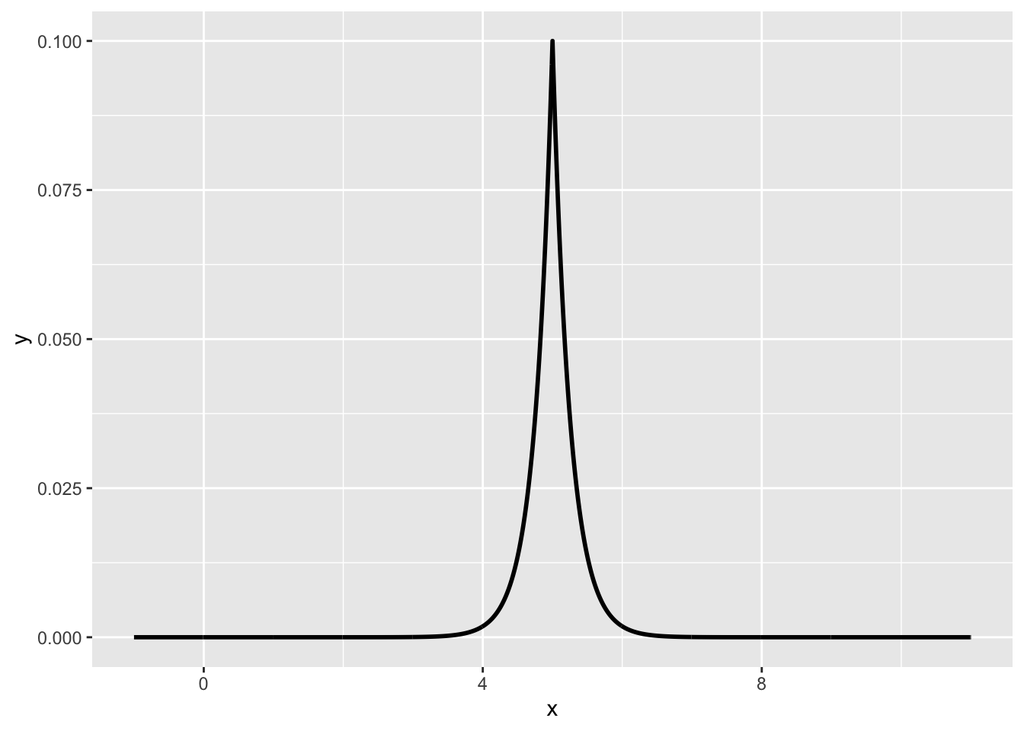

```r
desired_fun <- function(x){
  (exp(-2*abs(x-5)))^2/10
}
x <- seq(-1,11,by=0.01)
y <- desired_fun(x)
df <- data.frame(x,y)
ggplot(df, aes(x,y)) +
  # theme_minimal() +
  geom_line(size=1)
```

Consider a proposal distribution g: $\mathcal{N}(5,1)$

We’re going to do the following steps:

1. Draw n sample points $x$ from proposal distribution g using `rnorm()`
2. Define $f(x)$ and $g(x)$ (Using `dunif()` anf `dnorm()`)
3. Apply function $h^*$ on every sample points
4. Compute $\hat{\mu}=\frac{10}{n}\sum_{i=1}^nh^*(x)=\frac{1}{n}\sum_{i=1}^n\frac{f(x_i)}{g(x_i)}h(x_i)$

```r
n = 10000
x <- rnorm(n, mean=5, sd=1)
f <- function(x){
  dunif(x, 0, 10)
}
g<- function(x){
  dnorm(x, mean=5, sd=1)
}
h <- function(x){
  10*exp(-2*abs(x-5))
}

y = f(x)*h(x)/g(x)

c( mean(y), var(y) )
```

```
## [1] 0.9925341 0.3516557
```

## Stratified Sampling

Monte Carlo starts as a very simple method, much of the complexity in practice comes from trying to reduce the variance, to reduce the number of samples that have to be simulated to achieve a given accuracy.

- Antithetic variables
- Control variates
- Importance sampling
- Stratified sampling
- Latin hypercube
- Quasi-Monte Carlo

Sample size for each strata: it’ is best’s better to use more samples for strata with high variability.

### HW3 Exercise 5

Sometimes, it can be beneficial to divide the interval into pieces (strata). Consider
$$\int_{-3}^3 x^3(e^x-1) \; dx$$
.

First, we can try to use standard Monte Carlo integration with $n = 10,000$ iterations to approximate this integral. Call this approximate value $S_0$.

```r
u <- runif(10000, -3, 3)
S0 <- 6*mean(u^3*(exp(u)-1))
S0
```

```
## [1] 243.4236
```

```r
n<-100000
strata <- c()
for(i in 1:6){
  u <- runif(n/6,-4+i,-3+i)
  strata[i] <- mean(u^3*(exp(u)-1))
}
S1 <- sum(strata)
S1
```

```
## [1] 243.6761
```

Compare standard error of both estimates by repeating above steps 1000 times.

```r
n<-10000
nsim <- 1000
S0_boot <- c()
S1_boot <- c()
for(j in 1:nsim){
  u <- runif(n, -3, 3)
  S0_boot[j] <- 6*mean(u^3*(exp(u)-1))
  strata <- c()
  for(i in 1:6){
    u <- runif(n/6,-4+i,-3+i)
    strata[i] <- mean(u^3*(exp(u)-1))
  }
  S1_boot[j] <- 6*mean(strata)
}
E0<-sd(S0_boot)
E1<-sd(S1_boot)

E0
```

```
## [1] 5.757783
```

```r
E1
```

```
## [1] 3.199172
```